## Author: “Ravi , Miranda and Noe”

# Date: “March 29, 2018”

## Introduction

For this project we will explore the Montgomery, Maryland collision data to find which variables have the strongest effect on one another to better understand what does and does not effect the degree of a collision. We will provide graphs which visually represent the most interesting relationships between the variables in the dataset.

## Data Information

The data we are using is from data.montgomerycountymd.gov and breaks down the answers to the questions asked to drivers after they have been in a collision. The variables in the data set range from details on the location of the collision, the specifics of the car and the specifics of the drivers. The dataset was created in September 2017 and the data is collected via the Automated Crash Reporting System (ACRS) of the Maryland State Police. As of March 22, 2018, there are 66,600 rows and 32 columns in the database. Each row represents one driver.

## Initial Data Exploration

As we began to explore the dataset, each one of us tried to come up with different questions that we wanted to answer. It was helpful to be able to see what the dataset looked like on the website, but we gained the most important insight by writing r code that allowed us to quickly identify how much data was missing and what type of content made up each row and column.

## Data Cleaning and Preprocessing

In order to provide the most accurate graphs, we had to clean our data by identifying the rows and columns that had null or empty values and remove them. Each of the questions we wanted to answer required us to use only a few different columns from the dataset, so it was easier to make subsets that had only the information we needed.

## Data Exploration and Visualization

```r
> dat=read.csv("file:///C:/Users/Ravinder/Google Drive (rasingh@csumb.edu)/2018 Spring/Data Science/Project_1/Crash_Reporting_-_Drivers_Data.csv") #change via your source
```

### Type of Collision by Vehicle Damage Extent

##### By looking into the vehicle damage extent we were able to look further into what type of collision caused the most damages of the corresponding type. We thought this would be interesting to explore the types of collisions which cause the most damage and the types which cause the least

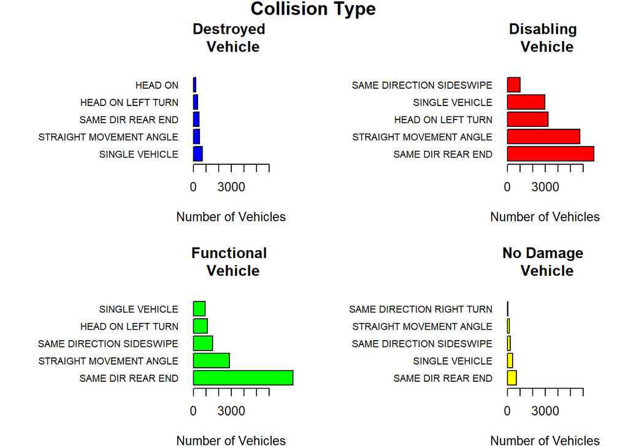

```r
> #new data frame without N/A and unknown of the Vehicle.Damage.Extend and other for Collision.Type
> datVDExCT=dat[dat$Vehicle.Damage.Extent!="N/A" & dat$Vehicle.Damage.Extent!="UNKNOWN" & dat$Collision.Type!="N/A" & dat$Collision.Type!="UNKNOWN" & dat$Collision.Type!="OTHER",]
> #table of the damages and collision types
> tbl1=table(datVDExCT$Vehicle.Damage.Extent, datVDExCT$Collision.Type)
> #graphing
> par(mar =c(4,13,5,3))
> par(mfrow =c(2,2))
> barplot(sort(tbl1[1,c(1:5,7:18)],decreasing = TRUE)[1:5], horiz=TRUE, las=1, main="Destroyed \n Vehicle",cex.names =.8, col="blue",xlab="Number of Vehicles",xlim=c(0,6000))
> barplot(sort(tbl1[2,c(1:5,7:18)],decreasing = TRUE)[1:5], horiz=TRUE, las=1, main= "Disabling \n Vehicle",cex.names =.8, col="red", xlab="Number of Vehicles", xlim=c(0,6000))
> barplot(sort(tbl1[3,c(1:5,7:18)],decreasing = TRUE)[1:5], horiz=TRUE, las=1, main="Functional \n Vehicle",cex.names =.8, col="green", xlab="Number of Vehicles", xlim=c(0,6000))
> barplot(sort(tbl1[5,c(1:5,7:18)],decreasing = TRUE)[1:5], horiz=TRUE, las=1, main="No Damage \n Vehicle",cex.names =.8, col="yellow", xlab="Number of Vehicles", xlim=c(0,6000))
> title("Collision Type", outer = TRUE, line=-1, cex.main=1.5)
```

## When do the most collisions occur in a given time period?

## The first graph shows how many collisions occur during each day of the week. Our first assumption was that the weekends would have the highest number of collisions because of substance abuse being more likely to happen on the weekends.

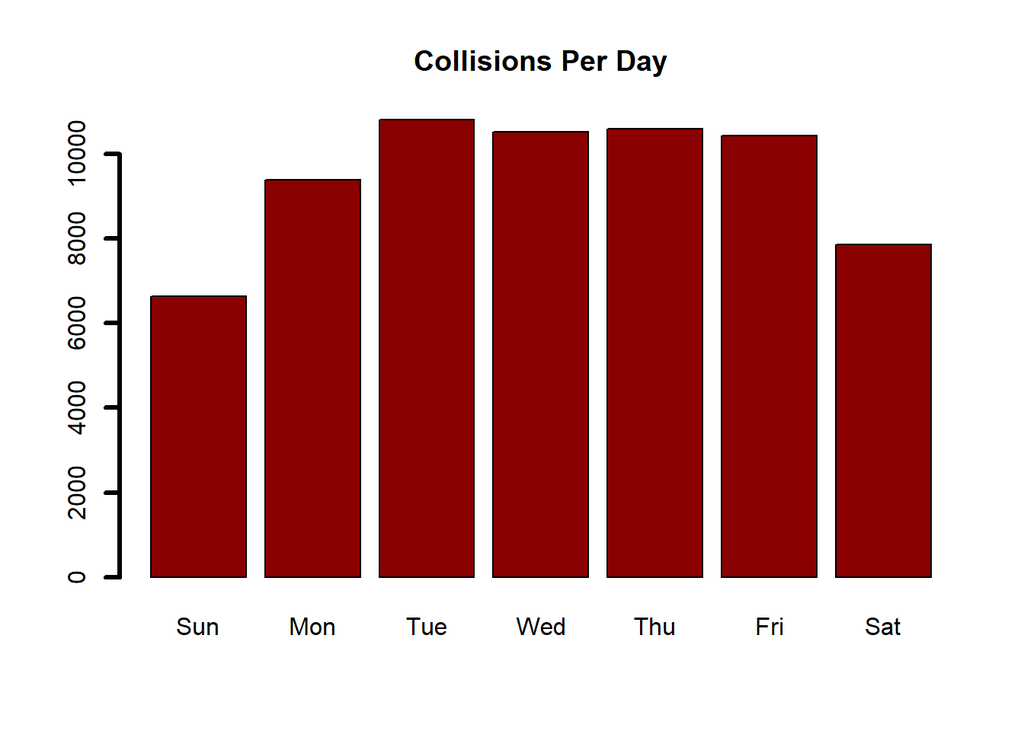

```r
> # Convert string values to POSIXlt objects
> dat$dtime = strptime(as.character(dat$Crash.Date.Time),
+ "%m/%d/%Y %I:%M:%S %p", tz="America/New_York")
> # Day of the Week
> barplot(table(dat$dtime$wday), main="Collisions Per Day",
+         names.arg = c("Sun", "Mon", "Tue", "Wed", "Thu", "Fri", "Sat"),
+         col="red4", lwd=3)
```

##Once we saw the graph we realized that there may be more collisions during the week because there are more drivers going to work than there are people going out to party.

## We were interested in finding out which month had the highest number of collisions. Our intuition told us that the holidays in December would be a big factor.

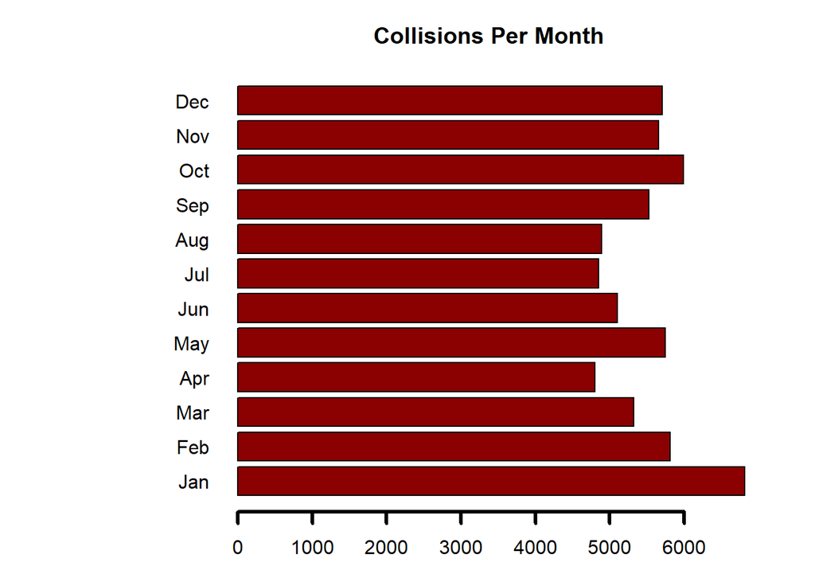

```r
> par(mar=c(3,10,3,3))
> barplot(table(dat$dtime$mon), main="Collisions Per Month",
+          names.arg = c("Jan", "Feb", "Mar", "Apr", "May", "Jun", "Jul",
+                       "Aug", "Sep", "Oct", "Nov", "Dec"),
+         col="red4", lwd=3, horiz=TRUE, las=1)
```

##We were expecting December to have the highest number, but it turned out that January has more collisions than any other month.

## We were really curious about what hour of the day had the most collisions. At first we guessed that the times when people drive to work and back home would be significantly higher.

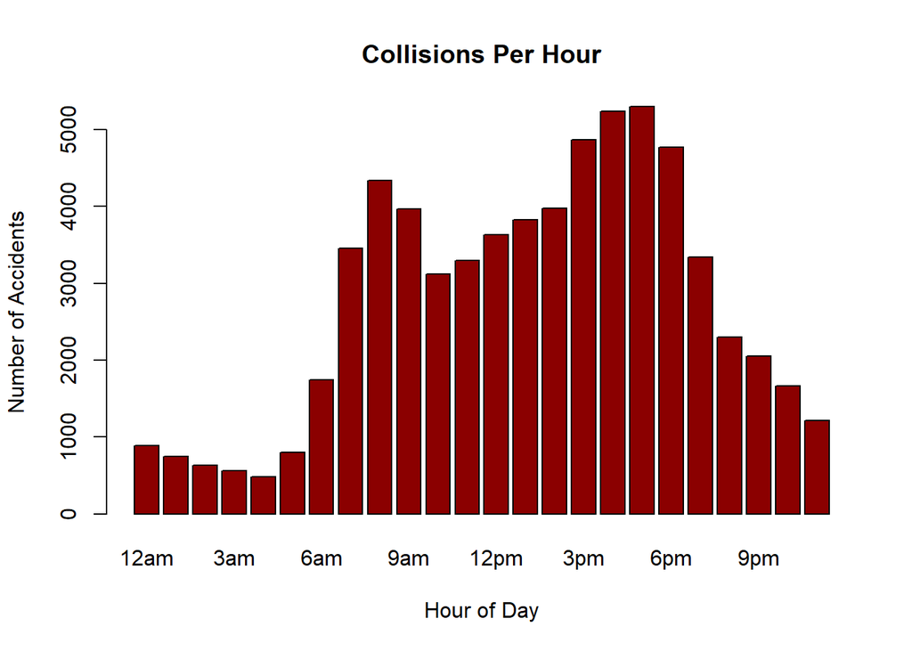

```r
> barplot(table(dat$dtime$hour), col="red4",
+ xlab="Hour of Day", ylab="Number of Accidents", main="Collisions Per Hour",
+ names.arg = c("12am", "1am", "2am", "3am", "4am", "5am", "6am",
+                       "7am", "8am", "9am", "10am", "11am",
+               "12pm", "1pm", "2pm", "3pm", "4pm", "5pm", "6pm",
+                       "7pm", "8pm", "9pm", "10pm", "11pm"))
```

##As we suspected, rush hour in the morning and the evening had the highest numbers.

## We also wanted to know if there was a year that had a significant difference among the others.

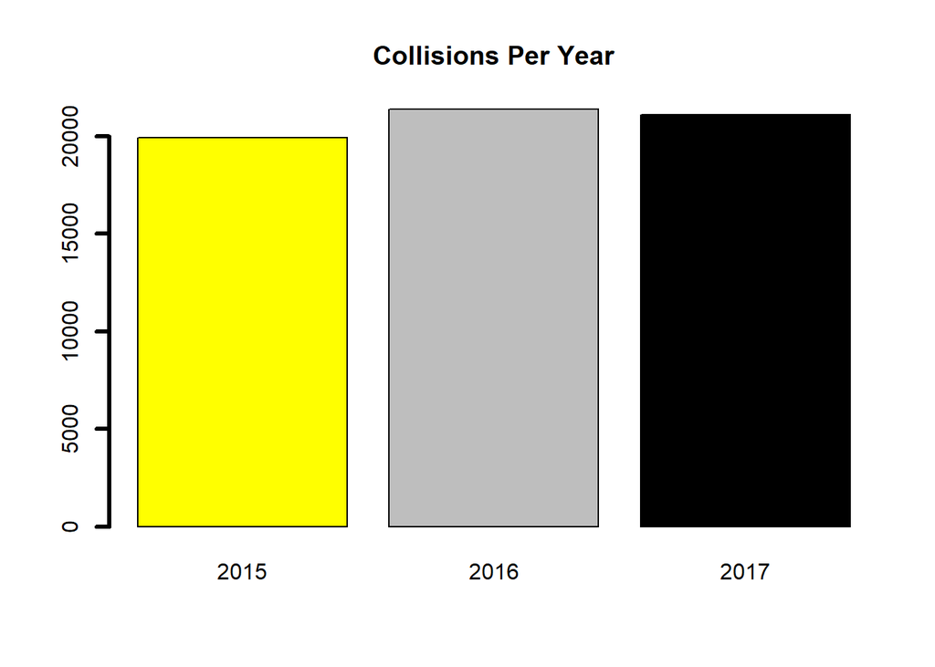

```r
> # Delete year 2018 to focus on years that have 12 months of data
> year15_18 <- as.data.frame(dat$dtime$year)
> year15_17 <- subset(year15_18, year15_18$`dat$dtime$year` != 118)
> # per year
> barplot(table(year15_17), main="Collisions Per Year",
+         names.arg = c("2015", "2016", "2017"),col=c(7:9), lwd=3)
```

##It turned out that the number of collisions was spread evenly across the years. This is the result we were expecting to find.

### Causes of Rear End Collisions

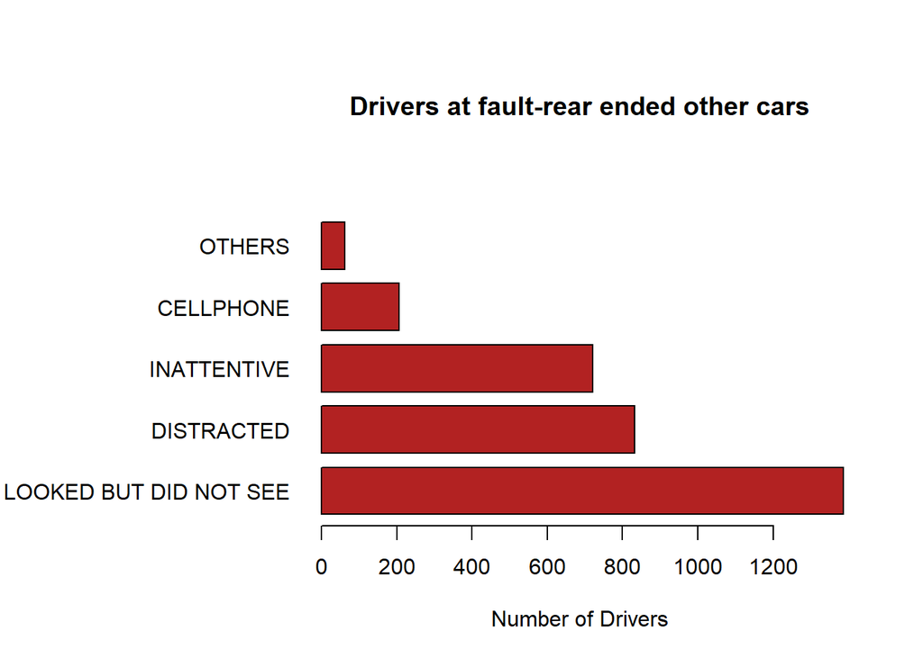

```r
> #look into vehicles with the same report number for the collision
> dat=read.csv("file:///C:/Users/Ravinder/Google Drive (rasingh@csumb.edu)/2018 Spring/Data Science/Project_1/Crash_Reporting_-_Drivers_Data.csv" , stringsAsFactors = FALSE )
> dat1 = dat
> #par(mfrow =c(1,1))
> par(mar= c(5,12,8,3))
> dat1$Driver.Distracted.By = as.character((dat1$Driver.Distracted.By))
> dat1 = dat1[dat1$Driver.Distracted.By != "UNKNOWN" & dat1$Driver.Distracted.By != "NOT DISTRACTED",]
> #New data frame for rear end accidents
> driver_fault = dat1[dat1$Collision.Type == "SAME DIR REAR END" & dat1$Driver.At.Fault == "Yes",]
> driver_fault = na.omit(driver_fault)
> #Renaming the values in the data frame
> driver_fault[grepl("TEXT|TALK|DEVICE|CELLULAR",as.character(driver_fault$Driver.Distracted.By)),] <- "CELLPHONE"
> driver_fault[grepl("BY|OTHER|MOVING|EATING",as.character(driver_fault$Driver.Distracted.By)),] <- "DISTRACTED"
> driver_fault[grepl("SMOKING|DRIVER|AUDIO",as.character(driver_fault$Driver.Distracted.By)),] <- "OTHERS"
> driver_fault[grepl("INATTENTIVE",as.character(driver_fault$Driver.Distracted.By)),] <- "INATTENTIVE"
> #graphing
> barplot(sort(table(substr(driver_fault$Driver.Distracted.By , start = 1 , stop = 22)), decreasing = TRUE), col ="firebrick" , las = 1 , horiz = TRUE , main = "Drivers at fault-rear ended other cars" , space = 0.3  , xlab = "Number of Drivers")
```

### Substance Abuse on Collision

##### After processing the data set, we saw there were many drivers who were using types of substances when they were in a collision. After seeing this we wanted to see if these drivers were more often the cause of the accident, in other word “at fault”.

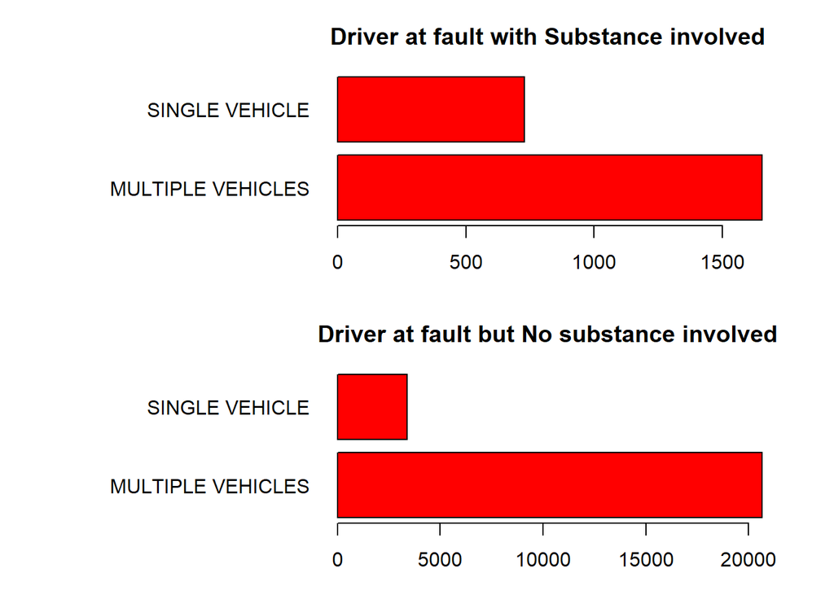

```r
> #Take out the NA's on the data set
> dat1 = na.omit(dat)
> par(mar =c(3,14,3,3))
> par(mfrow =c(2,1))
> Substance_drivers = dat1[dat1$Driver.At.Fault == "Yes" & dat1$Driver.Substance.Abuse != "NONE DETECTED" & dat1$Driver.Substance.Abuse !="N/A" & dat1$Driver.Substance.Abuse !="UNKNOWN",]
> Substance_drivers$Collision.Type[!(as.character(Substance_drivers$Collision.Type)) %in% "SINGLE VEHICLE"] = "MULTIPLE VEHICLES"
> No_substance_drivers = dat1[dat1$Driver.At.Fault == "Yes" & dat1$Driver.Substance.Abuse == "NONE DETECTED",]
> No_substance_drivers$Collision.Type[!(as.character(No_substance_drivers$Collision.Type)) %in% "SINGLE VEHICLE"] = "MULTIPLE VEHICLES"
> #Graphing
> barplot(sort(table(Substance_drivers$Collision.Type), decreasing = TRUE) , col ="red" , horiz = TRUE , las =1 , main = "Driver at fault with Substance involved",xlab = "Number of Drivers")
> barplot(sort(table(No_substance_drivers$Collision.Type), decreasing = TRUE) , col ="red" , horiz = TRUE , las =1 ,main = "Driver at fault but No substance involved" , xlab = "Number of Drivers")
```

## Do more vehicles get in accidents near a certain location? What could be the reason for this?

## We wanted to see if there was a correlation between a location and the type of traffic control at that point in the map. Would there be a clear indication of something that needs to be fixed on the roads?

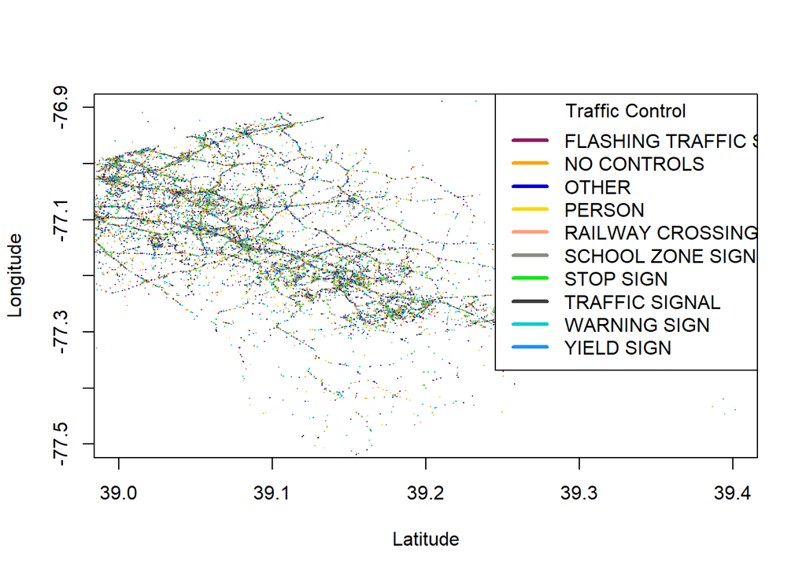

```r
> # Make a copy of dataset and remove N/A, empty fields and unknowns
> dat_nl = dat
> dat_nl$traffic = na.omit(dat_nl$Traffic.Control)
> row_to_keep = dat_nl$traffic == "N/A" | dat_nl$traffic == "UNKNOWN"
> traffic = dat_nl[!row_to_keep,]$Traffic.Control
> # vector of colors
> colors = c("maroon4", "orange1", "mediumblue", "gold1", "lightsalmon1",
+            "ivory4", "green2", "gray24", "darkturquoise", "dodgerblue1")
> # graph provides locations in the county where the collisions happened.
> #Color coded by type of accident
> plot(dat_nl$Latitude, dat_nl$Longitude, pch=".", xlim = c(39, 39.4), ylim = c(-77.5,-76.9),
+      col = colors, xlab="Latitude", ylab="Longitude")
> legend("topright", names(table(traffic)), inset=0,
+          lwd=3, col = colors, title="Traffic Control", text.width = .12)
```

### Weather Effects on Severity of Collision

##### After exploring the data set, we saw there were certain weather conditions where more collisions occured in. Since many similar categories existed in the data set we generalized the weather conditions into three broader catergories to examine the number of collisions. After doing so, we considered the number of days Maryland experienced the three types of weather conditions and added the corresponding probability of the weather condition to display the likeliness given the probability of the weather condition.

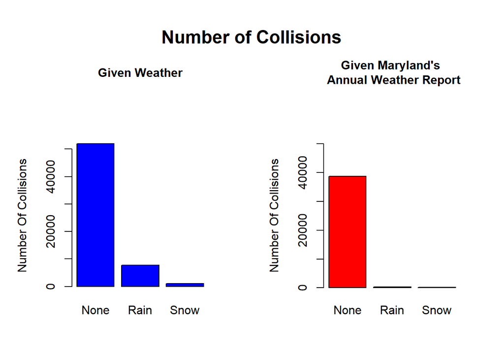

```r
> #new data frame without N/A and unknown of the weather
> datW=dat[dat$Weather!="N/A" & dat$Weather!="UNKNOWN" & dat$Collision.Type!="N/A" & dat$Collision.Type!= "UNKNOWN" & dat$Injury.Severity!= "N/A" & dat$Injury.Severity!= "UNKNOWN",]
> #create data frame of broader weather categories
> group6=data.frame(Weather=c("BLOWING SAND, SOIL, DIRT","BLOWING SNOW","CLEAR","CLOUDY","FOGGY","N/A","OTHER","RAINING","SEVERE WINDS","SLEET","SNOW","UNKNOWN","WINTRY MIX" ), type=c("None", "Snow", "None", "None", "None", "0", "0", "Rain", "None", "Rain", "Snow","0", "Snow"))
> #merge categories to data frame
> datWthr=merge(datW, group6, by='Weather')
> #weather in MRY probability
> #rain: 75.19/365=.206
> #Snow: 17.59/365=.048
> #None: 272.22/365=.746
> #looking at probabilities of weather conditions in MRY for accidents
> datMry=data.frame(type=c("0", "None", "Snow", "Rain"), Probs=c(0.000, 0.746, 0.048, 0.206))
> #Totals for each weather condition
> cond=table(datWthr$type)
> #Probabilities given MRY weather records
> condProbs=cond*datMry$Probs
> #graphs
> par(mfrow =c(1,2),ps = 12, cex = 1, cex.main = 1)
> par(mar =c(5,5,10,3))
> barplot(cond[2:4],main= "Given Weather", col="blue", ylab="Number Of Collisions")
> barplot(condProbs[2:4],main="Given Maryland's \n Annual Weather Report", col="red", ylim=c(0,50000),  ylab="Number Of Collisions")
> title("Number of Collisions", outer = TRUE, line=-3, cex.main=1.5)
```

### Likeliness of an Accident by Vehicle Classification

##### After examining the data set we saw not all vehicles were passenger vehicle. By providing broadened categories of the vehicles we looked into which types of vehicles got into the most collisions and how severe the collisions were. To see these correlations we looked at the injury severity of each collision and the types of collision per vehicle classification.

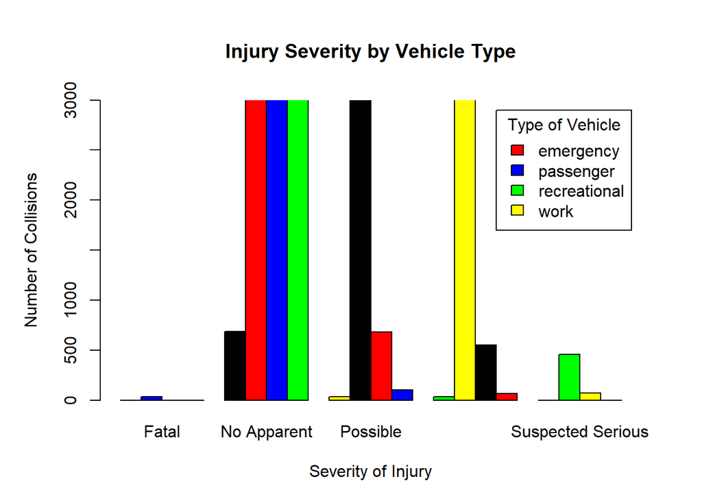

```r
> #Data frame without N/A, OTHER and UNKNOWN values for body type, collision type and injury severity
> datVBT=dat[dat$Vehicle.Body.Type!="N/A" & dat$Vehicle.Body.Type!="UNKNOWN" & dat$Collision.Type!="N/A" & dat$Collision.Type!="UNKNOWN" & dat$Injury.Severity!="N/A" & dat$Injury.Severity!="UNKNOWN" & dat$Collision.Type!="OTHER",]
> #assigns each vehicle body type to a more general group
> group=data.frame(Vehicle.Body.Type=c("","(SPORT) UTILITY VEHICLE","ALL TERRAIN VEHICLE (ATV)","AMBULANCE/EMERGENCY","AMBULANCE/NON EMERGENCY","AUTOCYCLE","CARGO VAN/LIGHT TRUCK 2 AXLES (OVER 10,000LBS (4,536 KG))","CROSS COUNTRY BUS","FARM VEHICLE","FIRE VEHICLE/EMERGENCY","FIRE VEHICLE/NON EMERGENCY","LIMOUSINE","LOW SPEED VEHICLE","MEDIUM/HEAVY TRUCKS 3 AXLES (OVER 10,000LBS (4,536KG))","MOPED","MOTORCYCLE","N/A","OTHER","OTHER BUS","OTHER LIGHT TRUCKS (10,000LBS (4,536KG) OR LESS)","PASSENGER CAR","PICKUP TRUCK","POLICE VEHICLE/EMERGENCY","POLICE VEHICLE/NON EMERGENCY","RECREATIONAL VEHICLE","SCHOOL BUS","SNOWMOBILE","STATION WAGON","TRANSIT BUS","TRUCK TRACTOR","UNKNOWN","VAN"), group=c("0","recreational", "recreational", "emergency", "work", "recreational", "passenger", "work", "work", "emergency", "work", "work", "recreational", "work", "recreational", "passenger", "0", "0", "work", "passenger", "passenger", "passenger", "emergency", "work", "recreational", "work", "recreational", "passenger", "work", "work", "0", "passenger"))
> #merging general groups to body type
> datCat=merge(datVBT,group, by='Vehicle.Body.Type')
> #create table of injury by vehicle group
> tbl7=table(datCat$group,datCat$Injury.Severity)
> colnames(tbl7)[1]="Fatal"
> colnames(tbl7)[2]="No Apparent"
> colnames(tbl7)[3]="Possible"
> colnames(tbl7)[4]="Suspected Minor"
> colnames(tbl7)[5]="Suspected Serious"
> #graphs of comparisons of injury severity
> par(mar =c(5,5,5,3))
> par(mfrow=c(1,1))
> barplot(tbl7[2:5,], legend=rownames(tbl7[2:5,]), beside=TRUE, col=c("red","blue","green","yellow","black"),ylim=c(0,3000) ,xpd=F, xlab="Severity of Injury",args.legend=list(title="Type of Vehicle"), main="Injury Severity by Vehicle Type", ylab="Number of Collisions")
```

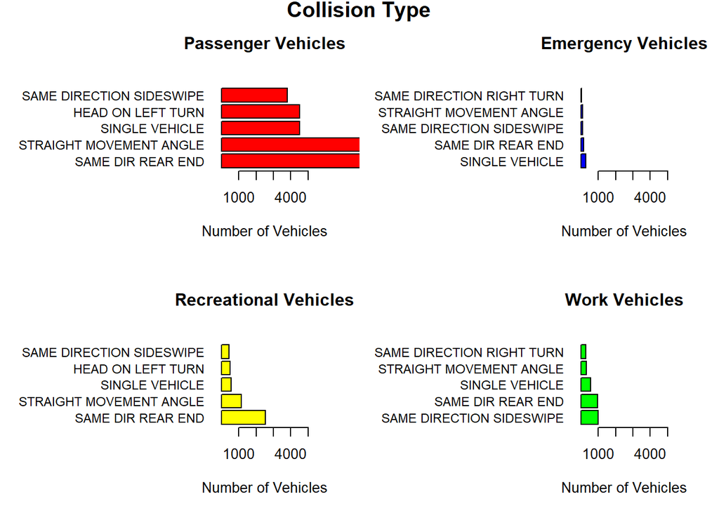

```r
> #create table of injury by vehicle group
> tbl7c=table(datCat$group,datCat$Collision.Type)
> #graph comparisons of collision types
> par(mar =c(5,13,5,3))
> par(mfrow =c(2,2))
> barplot(sort(tbl7c[3,],decreasing = TRUE)[1:5], horiz=TRUE, las=1, main="Passenger Vehicles",cex.names =.9, col="red",xlab="Number of Vehicles",xlim=c(1,5000))
> barplot(sort(tbl7c[2,],decreasing = TRUE)[1:5], horiz=TRUE, las=1, main="Emergency Vehicles",cex.names =.9, col="blue", xlab="Number of Vehicles",xlim=c(1,5000))
> barplot(sort(tbl7c[4,],decreasing = TRUE)[1:5], horiz=TRUE, las=1, main="Recreational Vehicles",cex.names =.9, col="yellow",xlab="Number of Vehicles",xlim=c(1,5000))
> barplot(sort(tbl7c[5,],decreasing = TRUE)[1:5], horiz=TRUE, las=1, main="Work Vehicles",cex.names =.9, col="green",xlab="Number of Vehicles", xlim=c(1,5000))
> title("Collision Type", outer = TRUE, line=-1, cex.main=1.5)
```

### Number of Collisions by Type of Vehicle

##### We looked to see what types of vehicles: cars, motorcycles or buses caused the most severe injuries in the collisions

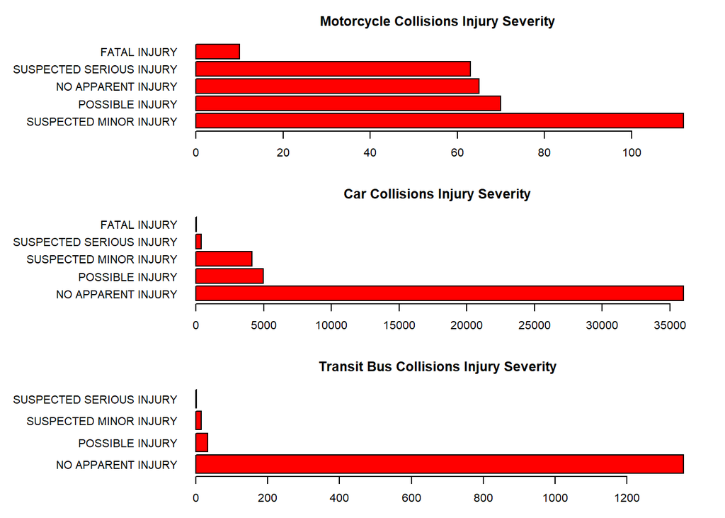

```r
> #Data frame without NA values
> dat1 = na.omit(dat)
> #Data sets by vehicle body
> car = dat1[dat1$Vehicle.Body.Type == "PASSENGER CAR",]
> motor = dat1[dat1$Vehicle.Body.Type == "MOTORCYCLE",]
> transit_bus = dat1[dat1$Vehicle.Body.Type == "TRANSIT BUS",]
> #graphs
> par(mar =c(3,14,3,3))
> par(mfrow =c(3,1))
> barplot(sort(table(motor$Injury.Severity), decreasing = TRUE),col = "red" , horiz = TRUE , las =1 ,main = "Motorcycle Collisions Injury Severity", xlab = "Number of Collisions")
> barplot(sort(table(car$Injury.Severity), decreasing = TRUE),col = "red" , horiz = TRUE , las =1 , main = "Car Collisions Injury Severity", xlab = "Number of Collisions")
> barplot(sort(table(transit_bus$Injury.Severity), decreasing = TRUE),col = "red" , horiz = TRUE , las =1 , main = "Transit Bus Collisions Injury Severity" , xlab = "Number of Collisions")
```

## If an accident did not occur on the street (i.e. shopping center, driveway, etc) what is it related to?

## We wanted to know if the collisions were caused by any particular situation more than others. Since these collisions did not happen on the roads, We were not expecting to see a lot of head collisions.

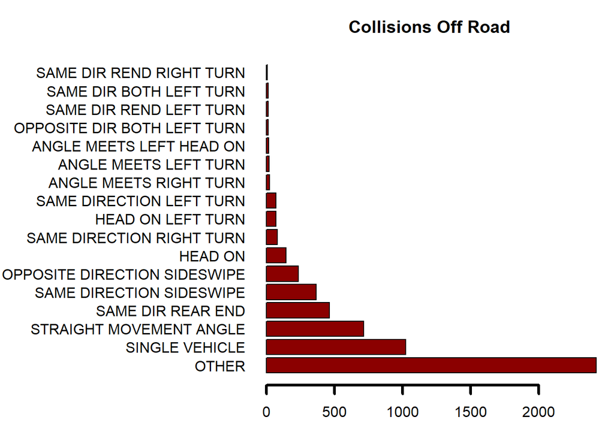

```r
> # Make a copy of dataset and remove N/A, empty fields and unknowns
> dat_nl2 = dat
> dat_nl2$traffic = na.omit(dat_nl2$Off.Road.Description)
> dat_nl2$collision = na.omit(dat_nl2$Collision.Type)
> rtk = dat_nl2$Collision.Type == "N/A"
> dat_nl2 = as.data.frame(dat_nl2[!rtk,])
> rtk2 = dat_nl2$Collision.Type == ""
> dat_nl2 = as.data.frame(dat_nl2[!rtk2,])
> rtk3 = dat_nl2$Collision.Type == "UNKNOWN"
> dat_nl2 = as.data.frame(dat_nl2[!rtk3,])
> # remove N/A, empty fields and unknowns in second column
> row_to_keep = dat_nl2$Off.Road.Description == "N/A"
> dat_nl2 = as.data.frame(dat_nl2[!row_to_keep,])
> row_to_keep2 = dat_nl2$Off.Road.Description == ""
> dat_nl2 = as.data.frame(dat_nl2[!row_to_keep2,])
> row_to_keep3 = dat_nl2$Off.Road.Description == "UNKNOWN"
> dat_nl2 = as.data.frame(dat_nl2[!row_to_keep3,])
> collisions = head(sort(table(dat_nl2$Collision.Type), decreasing = TRUE), 17)
> # graph the types of accidents that occur on parking lots and private roads.
> par(mar=c(3,15,3,1))
> barplot(collisions, main="Collisions Off Road",
+         col="red4", lwd=3, horiz=TRUE, las=1)
```

##The second cause of collisions was by single vehicles. We imagine these are times when people are backing out of parking spaces and hit something accidentally.

## Conclusion

After exploring and processing the data we learned although a data set may be large there can be various type of values within which do not help better understand the data set. For example, this data set had only one row containing “na” values, but it had many “N/A”, “UNKNOWN” and “OTHER” which did not help us better understand how the variables correlated. After much processing of the insignificant values we also found the parts of the data we guessed to be highly correlated had very little correlation after all. Overall, working with this data set was very fun and informative, but finding questions and correlations which satisfied our want to show the complexity and high correlation proved to be the biggest challenge of all.